# JP Morgan Chase Corporate Challenge - Intel in 2016

Aaron Ferrucci

September 11, 2016

## Intro

JP Morgan Chase sponsors a short footrace in San Francisco every September. This year Intel had about 60 runners amid a total of about 8000. Here’s an exploration of the race data.

#### Basic quantities

Number of runners: `7701`

Number of companies: `349`

The gender breakdown is a bit tilted toward male runners:

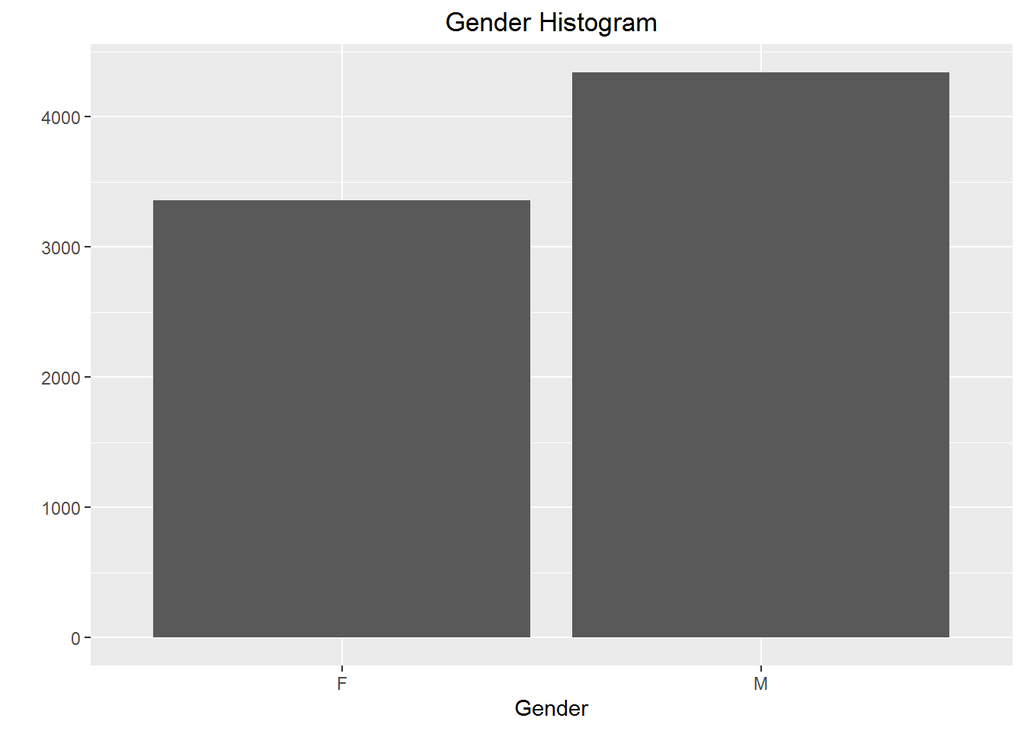

Summary of run times:

```
##      Min.   1st Qu.    Median      Mean   3rd Qu.      Max.
## "0:15:33" "0:25:41" "0:29:42" "0:31:55" "0:35:40" "1:17:57"
```

Summary of run times for Intel runners:

```
##      Min.   1st Qu.    Median      Mean   3rd Qu.      Max.
## "0:18:41" "0:24:26" "0:28:28" "0:29:01" "0:32:12" "0:45:00"
```

#### Participation by Company

Some companies fielded a large number of runners, and then there’s a long tail. Here’s the histogram of runners by company (I omitted company names from the X axis because they’d be illegible).

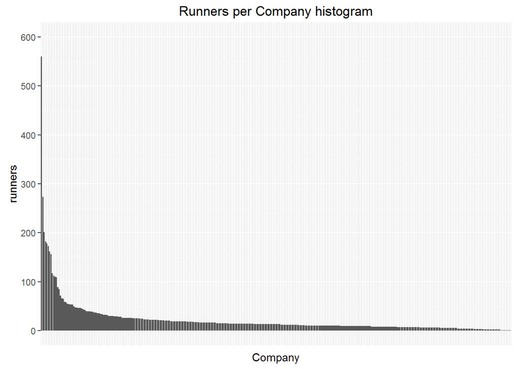

#### Top 20

Here are the 20 companies with the most runners. Salesforce is by far the biggest. Intel is #18!

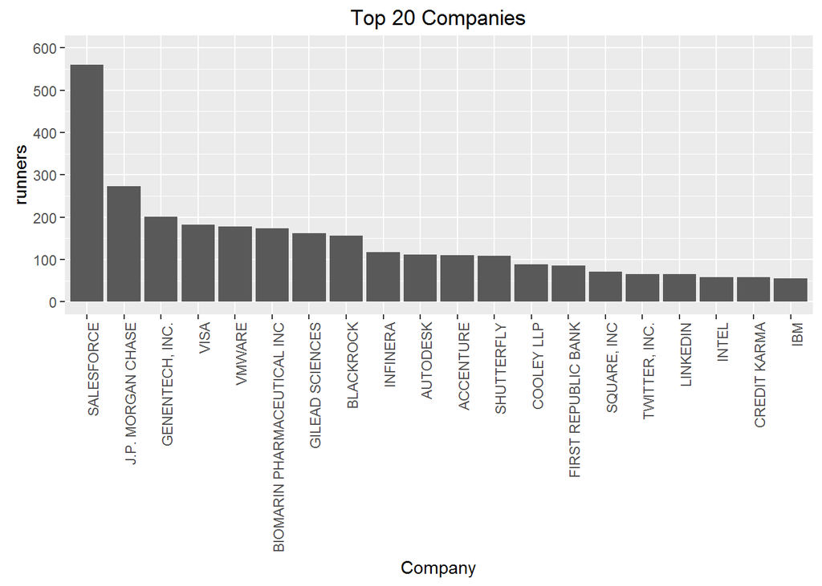

#### Bib Allocation

Faster runners (by self-reported estimate) were given red bibs, numbered 100 to 1100, and were allowed to start first. Everyone else got a white bib, and started in loosely organized stages. Bibs were assigned in groups, alphabetically, by company name and then by runner last name. The plot shows the grouping, roughly, by first letter of company name:

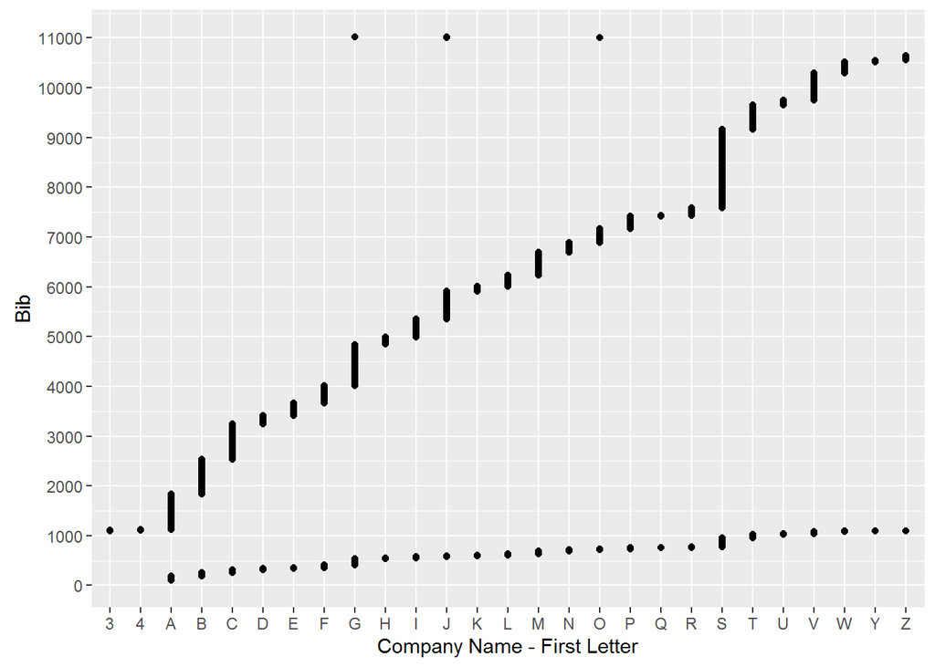

There are a few outliers with bib number 11000 and greater. Just three companies are represented there:

```
## [1] "ON BOARD EXPERIENTIAL MARKETING" "J.P. MORGAN CHASE"
## [3] "GAP INC"
```

All of ON BOARD EXPERIENTIAL MARKETING’s runners were in the above-11000 category, while the other two companies do have some lower bib numbers. There was probably some last-minute scheduling going on here.

#### Elapsed Time

Here’s a look at runner elapsed time. Since bib numbers were assigned per company in blocks, runners in the same company are in the same X region. As in most races, gender is a predictor of run time. Also, it’s clear that low bib numbers (red bibs) do tend to have shorter elapsed time. Intel runners are marked in black.

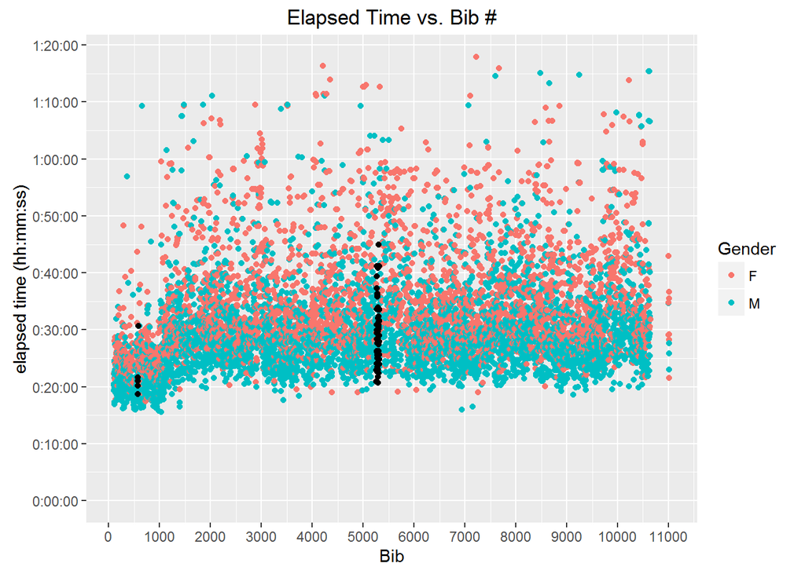

Another way to view the runner elapsed time is by plotting rank vs. run time. This plot gives a sense of the distribution of runner times - a small group of faster runners, a somewhat flat middle section, and then a sharply rising right-hand end. Again, I colored Intel runners in black.

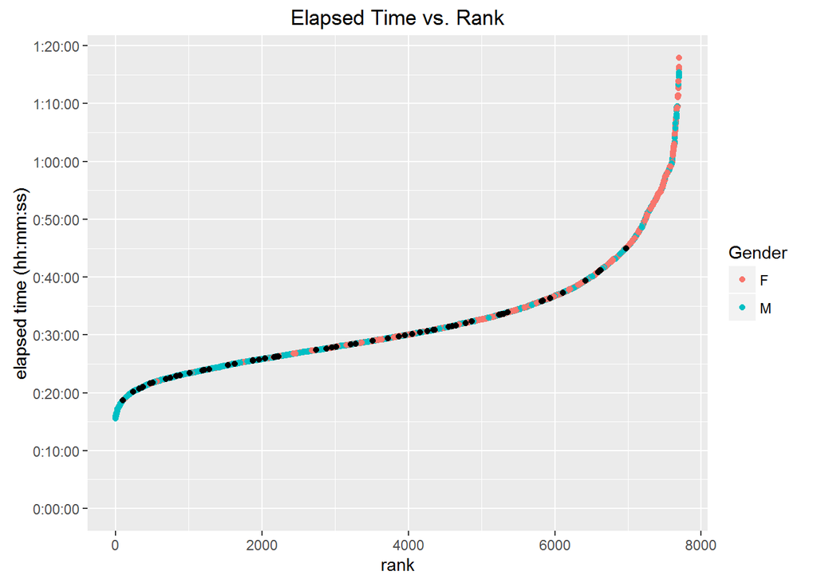

#### References

1. JP Morgan Chase Corporate Challenge website: https://www.jpmorganchasecc.com
2. Interactive visualization: https://aaronferrucci.shinyapps.io/jpmcc2016_shiny/
3. Source code: https://github.com/aaronferrucci/jpmcc2016